# Signal quality metrics and channel rejection

This work is based on the excellent tutorials created by the MNE and MNE-NIRS developers:

- **MNE**: [Tutorials](https://mne.tools/stable/auto_tutorials/index.html)
- **MNE-NIRS**: [Examples](https://mne.tools/mne-nirs/stable/auto_examples/index.html)
- Pre-processing
  - Load python modules
  - Import data
    - Import snirf data
    - Add info to raw intensity data
  - Visual inspection
    - Physiological noise
    - Spikes
    - Baseline shifts
    - Baseline drift
  - Signal quality metrics and channel rejection
    - Scalp Coupling Index
    - Peak Spectral Power

## Pre-processing

### Load python modules

```python
# Import the needed modules
import numpy as np
import pandas as pd
import matplotlib.pyplot as plt
import seaborn as sns
import mne
import mne_nirs
import pywt
import scipy
import dabest
from itertools import compress
from mne.preprocessing.nirs import scalp_coupling_index, optical_density, temporal_derivative_distribution_repair, beer_lambert_law, _validate_nirs_info
from mne_nirs.preprocessing import peak_power, scalp_coupling_index_windowed, quantify_mayer_fooof
from mne_nirs.visualisation import plot_timechannel_quality_metric
from mne_nirs.channels import get_short_channels, get_long_channels, picks_pair_to_idx
from mne_nirs.signal_enhancement import short_channel_regression
from mne.preprocessing import ICA, corrmap
from scipy.stats import norm, ttest_1samp, kurtosis, pearsonr
from scipy.signal import wiener
from scipy.interpolate import CubicSpline
from fooof import FOOOF
from csaps import csaps
from sklearn.decomposition import PCA, FastICA
from sklearn.preprocessing import StandardScaler
import dataframe_image as dfi
```

```python
# Write own functions
def reorder(raw_initial):
    """
    Input: raw object
    Function: reorders the channels to match the MNE standard
    """
    raw = raw_initial.copy()
    channel_names = raw.ch_names
    channel_names_ordered = []
    for i in range(0, int(len(channel_names)/2)):
        channel_names_ordered.append(channel_names[i])
        channel_names_ordered.append(channel_names[(i + int(len(channel_names)/2))])
    raw_ordered = raw.reorder_channels(channel_names_ordered)
    return raw_ordered

def add_info(raw_intensity, first_name, last_name, age, sex, EHI, annotations, duration_annotation, duration_rest, N_control):
    """
    Input: raw object, first name, last name, age, sex, EHI, annotations, duration of annotation, duration of baseline period, # of control trials
    Function: Returns raw object with added subject info and random allocated control trials within the baseline period
    """
    raw = raw_intensity.copy()

    # Add subject info
    raw.info["subject_info"] = {'first_name' : first_name, 'last_name' : last_name, 'age' : age, 'sex' : sex, 'EHI' : EHI}

    # attribute meaningful names to trigger codes. Include information about the duration of each stimulus (10 seconds).
    raw.annotations.set_durations(duration_annotation)
    raw.annotations.rename(annotations)

    events, event_dict = mne.events_from_annotations(raw)

    # Define begin and end of rest period
    begin_rest = np.ceil(events[np.where(events[:,2] == event_dict['Baseline'])[0][0],0]/raw.info['sfreq'])
    end_rest = begin_rest + duration_rest - duration_annotation

    # Remove start indicator of rest period
    raw.annotations.delete(np.nonzero(raw.annotations.description == "Baseline"))

    # Define indices of random selected control trials
    indices = np.random.choice(np.arange(begin_rest, end_rest), N_control, replace = False).astype(int)
    raw.annotations.append(indices, [duration_annotation]*N_control, ["Baseline"]*N_control)

    return raw

def crop(raw_input, t_before = 10, t_after = 60):
    """
    Input: raw object, time interval length before first event and time interval length after last event that should be included in the recording
    Function: crops raw object to a recording starting 't_before' s (default 10 s) before the first annotated event and ending 't_after' s (default 60 s) after the last event
    """
    raw = raw_input.copy()
    end_rec = raw.get_data().shape[1]/raw.info['sfreq']
    t_start = events[0,0]/raw.info['sfreq'] - t_before
    t_end = events[-1,0]/raw.info['sfreq'] + t_after
    if t_start < 10:
        t_start = 0
    if t_end > end_rec:
        t_end = end_rec
    raw.crop(t_start, t_end)
    return raw

def get_indices(array, target_array):
    """
    Input: complete array of channel names, array of channels names to be removed
    Function: gives back indices of desired channels
    """
    lst = list(array)
    indices = list(np.arange(0, len(array)))
    for target in target_array:
        if target in lst:
            indices.remove(lst.index(target))
    return indices

def ch_names_L_R(raw):
    """
    Input: raw object
    Function: Separate list of channel names in 2 lists for the left and right hemisphere respectively
    """
    left, right = [], []
    for ch in raw.ch_names:
        if (int(ch[1]) % 2) == 0:
            right.append(ch)
        else:
            left.append(ch)
    return left, right

def scale_up_spectra(spectra, freqs):
    """
    Input: spectra, freqs
    Function: FOOOF requires the frequency values to be higher than the fNIRS data permits,
    so we scale the values up by 10 here, and then will scale
    the frequency values down by 10 later.
    """
    freqs = freqs * 10
    return spectra, freqs

def get_IMU_data(filename, plot = False):
    """
    Extract IMU data from text file.
    Input: filename with .txt, plot (bool)
    Output: Three dataframes containing the complete IMU data, the accelerometer data and the gyroscope data respectively
    """

    # Read .txt file and convert to dataframe
    df = pd.read_csv(filename, sep=';', header=None, names=["time", "battery", "channels", "gyroX", "gyroY", "gyroZ", "accX", "accY", "accZ", "marker", "_"])

    # Select IMU data
    data = df.drop(0)
    markers = data["marker"].astype(float)
    IMU_data = data.drop(columns =['time', 'battery', 'channels', 'marker', '_']).astype(float)

    gyro_data = IMU_data.drop(columns = ['accX', 'accY', 'accZ'])
    acc_data = IMU_data.drop(columns = ["gyroX", "gyroY", "gyroZ"])

    if plot:
        %matplotlib inline
        gyro_data.plot(title='Gyroscope data', grid = True, xlabel = 'samples', ylabel = 'dps')
        acc_data.plot(title='Accelerometer data', grid = True, xlabel = 'samples', ylabel = 'm/s^2')

    return IMU_data, acc_data, gyro_data

def plot_SNR(raw, scores, times, threshold=0.1):
    """
    Plot time x channel based quality metrics.

    The left figure shows the raw score per channel and time.

    Parameters
    ----------
    raw : instance of Raw
        The haemoglobin data.
    scores : array
        The quality metric scores.
    times : list of pairs
        Start and end time for each quality metric.
    threshold : float
        Value below which a segment will be marked as bad.
    title : str
        Title of plot. If not specified a default title will be used.

    Returns
    -------
    fig : figure
        Matplotlib figure displaying raw scores and thresholded scores.
    """

    ch_names = raw.ch_names
    cols = [np.round(t[0]) for t in times]

    title = 'SNR'

    data_to_plot = pd.DataFrame(data=scores,
                                columns=pd.Index(cols, name='Time (s)'),
                                index=pd.Index(ch_names, name='Channel'))

    n_chans = len(ch_names)
    vsize = 0.2 * n_chans

    # First, plot the "raw" scores.
    fig, ax = plt.subplots(1, 2, figsize=(20, vsize), layout='constrained')
    fig.suptitle(title, fontsize=16, fontweight='bold')
    sns.heatmap(data=data_to_plot, cmap='Reds_r', vmin=np.min(scores), vmax=np.max(scores),
                cbar_kws=dict(label='Score'), ax=ax[0])
    [ax[0].axvline(x, ls='dashed', lw=0.25, dashes=(25, 15), color='gray')
        for x in range(1, len(times))]
    ax[0].set_title('All Scores', fontweight='bold')
    markbad(raw, ax[0])

    # Now, adjust the color range to highlight segments that exceeded the
    # limit.

    data_to_plot = pd.DataFrame(data=scores > threshold,
                                columns=pd.Index(cols, name='Time (s)'),
                                index=pd.Index(ch_names, name='Channel'))
    sns.heatmap(data=data_to_plot, vmin=0, vmax=1,
                cmap='Reds_r', cbar_kws=dict(label='Score'), ax=ax[1])
    [ax[1].axvline(x, ls='dashed', lw=0.25, dashes=(25, 15), color='gray')
        for x in range(1, len(times))]
    ax[1].set_title('Scores < Limit', fontweight='bold')
    markbad(raw, ax[1])

    return fig

def markbad(raw, ax):

    [ax.axhline(y + 0.5, ls='solid', lw=2, color='black') for y in np.where([ch in raw.info['bads'] for ch in raw.ch_names])[0]]

    return ax

def plot_CV(raw, scores, times, threshold=0.1):
    """
    Plot time x channel based quality metrics.

    The left figure shows the raw score per channel and time.

    Parameters
    ----------
    raw : instance of Raw
        The haemoglobin data.
    scores : array
        The quality metric scores.
    times : list of pairs
        Start and end time for each quality metric.
    threshold : float
        Value below which a segment will be marked as bad.
    title : str
        Title of plot. If not specified a default title will be used.

    Returns
    -------
    fig : figure
        Matplotlib figure displaying raw scores and thresholded scores.
    """

    ch_names = raw.ch_names
    cols = [np.round(t[0]) for t in times]

    title = 'CV'

    data_to_plot = pd.DataFrame(data=scores,
                                columns=pd.Index(cols, name='Time (s)'),
                                index=pd.Index(ch_names, name='Channel'))

    n_chans = len(ch_names)
    vsize = 0.2 * n_chans

    # First, plot the "raw" scores.
    fig, ax = plt.subplots(1, 2, figsize=(20, vsize), layout='constrained')
    fig.suptitle(title, fontsize=16, fontweight='bold')
    sns.heatmap(data=data_to_plot, cmap='Reds_r', vmin=np.min(scores), vmax=np.max(scores),
                cbar_kws=dict(label='Score'), ax=ax[0])
    [ax[0].axvline(x, ls='dashed', lw=0.25, dashes=(25, 15), color='gray')
        for x in range(1, len(times))]
    ax[0].set_title('All Scores', fontweight='bold')
    markbad(raw, ax[0])

    # Now, adjust the color range to highlight segments that exceeded the
    # limit.

    data_to_plot = pd.DataFrame(data=scores < threshold,
                                columns=pd.Index(cols, name='Time (s)'),
                                index=pd.Index(ch_names, name='Channel'))
    sns.heatmap(data=data_to_plot, vmin=0, vmax=1,
                cmap='Reds_r', cbar_kws=dict(label='Score'), ax=ax[1])
    [ax[1].axvline(x, ls='dashed', lw=0.25, dashes=(25, 15), color='gray')
        for x in range(1, len(times))]
    ax[1].set_title('Scores > Limit', fontweight='bold')
    markbad(raw, ax[1])

    return fig
```

```python
# Set plot characteristics
%matplotlib inline
sns.set_theme() # nicer plots
# Load external plots?
plot = False
# Export figures?
export = False
```

### Import data

#### Import snirf data

```python
filename = 'FTT3.snirf'
```

```python
# Read snirf data
raw = mne.io.read_raw_snirf(filename, optode_frame='unknown', preload=False, verbose=None)
```

```
Loading C:\Users\fabia\fNIRS data analysis\Notebooks Master Thesis - Fabian Duren\FTT analysis\FTT3\FTT3.snirf
```

```python
# Reorder channels (Due to non-uniformity between mne_nirs and .snirf data)
raw_intensity = reorder(raw)
```

#### Add info to raw intensity data

```python
# Use self-written function to add info about the subject and the recording
annotations = {"1": "practice/Left", "2": "practice/Right", "3": "practice/Control", "4": "Grasping/Left", "5": "Grasping/Right", "6": "Grasping/Control", "7": "Baseline"}
raw_intensity = add_info(raw_intensity, 'Subject', '1', 22, 'female', 'left', annotations, 12, 120, 10)
```

```
Used Annotations descriptions: ['Baseline', 'Grasping/Control', 'Grasping/Left', 'Grasping/Right', 'practice/Control', 'practice/Left', 'practice/Right']
```

```python
# Look at characteristics
raw_intensity
```

**General**

| Measurement date | May 08, 2024 12:56:44 GMT |
| --- | --- |
| Experimenter | Unknown |
| Participant |  |

**Channels**

| Digitized points | 20 points |
| --- | --- |
| Good channels | 52 fNIRS (CW amplitude) |
| Bad channels | None |
| EOG channels | Not available |
| ECG channels | Not available |

**Data**

| Sampling frequency | 5.65 Hz |
| --- | --- |
| Highpass | 0.00 Hz |
| Lowpass | 2.82 Hz |
| Filenames | romane_vorwald fft_22_20240508-125644.snirf |
| Duration | 00:21:09 (HH:MM:SS) |

```
Used Annotations descriptions: ['Baseline', 'Grasping/Control', 'Grasping/Left', 'Grasping/Right', 'practice/Control', 'practice/Left', 'practice/Right']
```

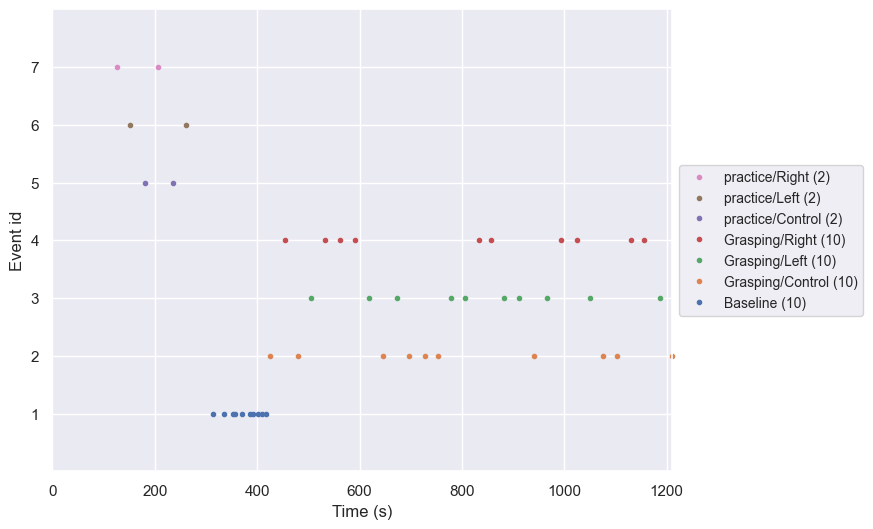

```python
# Look at segments
events, event_dict = mne.events_from_annotations(raw_intensity)
plt.rcParams["figure.figsize"] = (10, 6) # (w, h)
fig = mne.viz.plot_events(events, event_id=event_dict, sfreq=raw_intensity.info['sfreq'])
if export:
    fig.savefig('events_FTT3.png')
```

```python
# As a table
raw_intensity.annotations.to_data_frame()
```

|  | onset | duration | description |
| --- | --- | --- | --- |
| 0 | 2024-05-08 12:58:50.201 | 12.0 | practice/Right |
| 1 | 2024-05-08 12:59:16.220 | 12.0 | practice/Left |
| 2 | 2024-05-08 12:59:44.717 | 12.0 | practice/Control |
| 3 | 2024-05-08 13:00:09.851 | 12.0 | practice/Right |
| 4 | 2024-05-08 13:00:39.233 | 12.0 | practice/Control |
| 5 | 2024-05-08 13:01:05.075 | 12.0 | practice/Left |
| 6 | 2024-05-08 13:02:03.000 | 12.0 | Baseline |
| 7 | 2024-05-08 13:02:15.000 | 12.0 | Baseline |
| 8 | 2024-05-08 13:02:22.000 | 12.0 | Baseline |
| 9 | 2024-05-08 13:02:27.000 | 12.0 | Baseline |
| 10 | 2024-05-08 13:02:51.000 | 12.0 | Baseline |
| 11 | 2024-05-08 13:03:02.000 | 12.0 | Baseline |
| 12 | 2024-05-08 13:03:08.000 | 12.0 | Baseline |
| 13 | 2024-05-08 13:03:13.000 | 12.0 | Baseline |
| 14 | 2024-05-08 13:03:17.000 | 12.0 | Baseline |
| 15 | 2024-05-08 13:03:30.000 | 12.0 | Baseline |
| 16 | 2024-05-08 13:03:48.800 | 12.0 | Grasping/Control |
| 17 | 2024-05-08 13:04:18.182 | 12.0 | Grasping/Right |
| 18 | 2024-05-08 13:04:42.962 | 12.0 | Grasping/Control |
| 19 | 2024-05-08 13:05:08.981 | 12.0 | Grasping/Left |
| 20 | 2024-05-08 13:05:36.416 | 12.0 | Grasping/Right |
| 21 | 2024-05-08 13:06:06.683 | 12.0 | Grasping/Right |
| 22 | 2024-05-08 13:06:35.180 | 12.0 | Grasping/Right |
| 23 | 2024-05-08 13:07:02.615 | 12.0 | Grasping/Left |
| 24 | 2024-05-08 13:07:29.519 | 12.0 | Grasping/Control |
| 25 | 2024-05-08 13:07:56.246 | 12.0 | Grasping/Left |
| 26 | 2024-05-08 13:08:21.203 | 12.0 | Grasping/Control |
| 27 | 2024-05-08 13:08:51.470 | 12.0 | Grasping/Control |
| 28 | 2024-05-08 13:09:18.020 | 12.0 | Grasping/Control |
| 29 | 2024-05-08 13:09:42.977 | 12.0 | Grasping/Left |
| 30 | 2024-05-08 13:10:10.589 | 12.0 | Grasping/Left |
| 31 | 2024-05-08 13:10:36.431 | 12.0 | Grasping/Right |
| 32 | 2024-05-08 13:11:01.388 | 12.0 | Grasping/Right |
| 33 | 2024-05-08 13:11:26.345 | 12.0 | Grasping/Left |
| 34 | 2024-05-08 13:11:54.842 | 12.0 | Grasping/Left |
| 35 | 2024-05-08 13:12:25.109 | 12.0 | Grasping/Control |
| 36 | 2024-05-08 13:12:50.420 | 12.0 | Grasping/Left |
| 37 | 2024-05-08 13:13:17.855 | 12.0 | Grasping/Right |
| 38 | 2024-05-08 13:13:48.122 | 12.0 | Grasping/Right |
| 39 | 2024-05-08 13:14:14.849 | 12.0 | Grasping/Left |
| 40 | 2024-05-08 13:14:39.806 | 12.0 | Grasping/Control |
| 41 | 2024-05-08 13:15:07.418 | 12.0 | Grasping/Control |
| 42 | 2024-05-08 13:15:33.260 | 12.0 | Grasping/Right |
| 43 | 2024-05-08 13:15:59.810 | 12.0 | Grasping/Right |
| 44 | 2024-05-08 13:16:30.077 | 12.0 | Grasping/Left |
| 45 | 2024-05-08 13:16:55.034 | 12.0 | Grasping/Control |

##### Adress problem with timing of fNIRS recording

The stimulus presentation software PsychoPy was used to set-up this experiment. In the third finger-tapping task, each stimulus in the sequence was displayed for 12 seconds, followed by a blank screen for a duration between 17-23 seconds, before presenting the next stimuli. However, in the *.snirf* file the stimuli are not as expected.

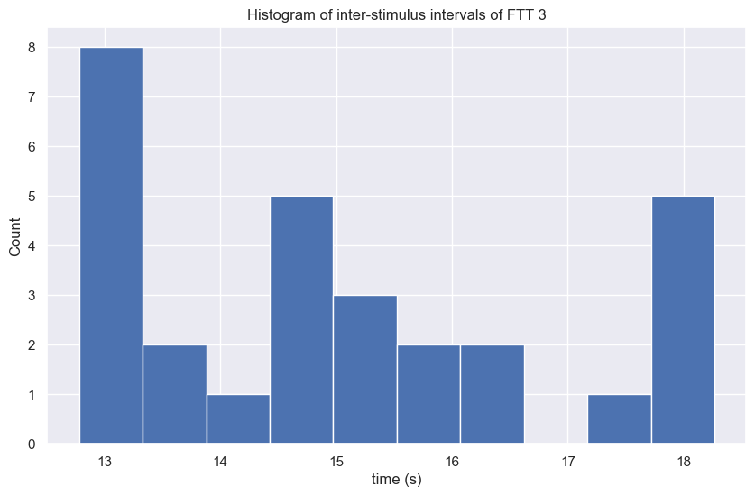

```python
# Get IDs of events
ids = [event_dict['Grasping/Control'], event_dict['Grasping/Left'], event_dict['Grasping/Right']]
# Determine inter-stimuli intervals
inter_stim = np.diff(events[np.isin(events[:,2], ids)][:,0])/raw_intensity.info['sfreq'] - 12
if plot:
    # plot
    plt.hist(inter_stim)
    plt.xlabel('time (s)')
    plt.ylabel('Count')
    plt.title('Histogram of inter-stimulus intervals of FTT 3')
    if export:
        plt.savefig('Histogram_inter_stimuli_FTT3.png')
```

> *Remark:*
- 26 channels * 2 wavelengths = 52 channels
- sample frequency = 5.65 Hz
- LPF = 2.82 Hz - Related to max bandwidth (Nyquist theorem): $F_{max} = \frac{F_s}{2}$
- 10 random selected control segments within the baseline recording period
- 10 left hand grasping segments, 10 right hand grasping segments and 10 control segments in random order

### Visual inspection

##### Validate that the location of sources-detector pairs and channels are in the expected locations

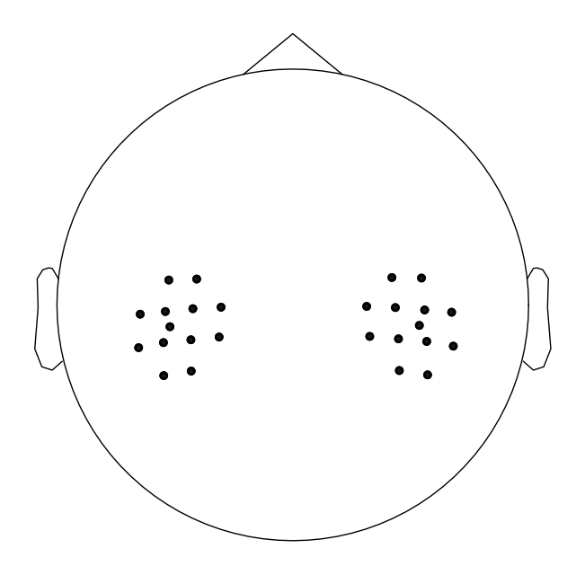

```python
# Plot channels in 2D using build-in function of mne_nirs
sns.reset_defaults() # Turn of sns to be able to also plot contour of head
# dots = Center of channels
%matplotlib inline
raw_intensity.plot_sensors();
```

```python
sns.set_theme()
if plot:
    # Plot channels in 3D
    subjects_dir = mne.datasets.sample.data_path() / "subjects"
    mne.datasets.fetch_fsaverage(subjects_dir=subjects_dir)

    brain = mne.viz.Brain("fsaverage", subjects_dir=subjects_dir, alpha=0.5, cortex="low_contrast")
    brain.add_head()

    identity_trans = mne.transforms.Transform("head", "mri") #transformed coord
    brain.add_sensors(raw_intensity.info, trans=identity_trans, fnirs=["channels", "pairs", "sources", "detectors"])

    # Add ROI: BA 1, 2, 3 - Primary somatosensory cortex (postcentral gyrus)
            # BA 4 - Primary motor cortex (precentral gyrus)
            # BA 5 - Somatosensory association cortex (NOT PRESENT IN LABELS)
            # BA 6	Premotor and supplementary motor cortex
    brain.add_label("BA1", hemi = "lh", borders=False, color='red')
    brain.add_label("BA1", hemi = "rh", borders=False, color='red')
    brain.add_label("BA2", hemi = "rh", borders=False, color='orange')
    brain.add_label("BA2", hemi = "lh", borders=False, color='orange')
    brain.add_label("BA3a", hemi = "rh", borders=False, color='yellow')
    brain.add_label("BA3b", hemi = "rh", borders=False, color='yellow')
    brain.add_label("BA3a", hemi = "lh", borders=False, color='yellow')
    brain.add_label("BA3b", hemi = "lh", borders=False, color='yellow')
    brain.add_label("BA4a", hemi = "lh", borders=False, color='green')
    brain.add_label("BA4a", hemi = "rh", borders=False, color='green')
    brain.add_label("BA4p", hemi = "lh", borders=False, color='green')
    brain.add_label("BA4p", hemi = "rh", borders=False, color='green')
    brain.add_label("BA6", hemi = "lh", borders=False, color='blue')
    brain.add_label("BA6", hemi = "rh", borders=False, color='blue')
    brain.show_view(azimuth=90, elevation=90, distance=500)
```

> *Remark:*
- 24 long channels and 2 short channels
- 8 sources, 10 detectors and 2 short channel sources
- montage located above sensorimotor cortex

##### Visual inspection of the raw light intensity data

```python
# Plot raw data with build-in plot function of mne_nirs
if plot:
    %matplotlib qt
    raw_intensity.plot(duration=20, show_scrollbars = True, clipping = None);
```

```
Channels marked as bad:
none
```

> *Remark:*
- Physiological components: Oscillations due to heart rate, Mayer waves
- Extrinsic components: Spikes due to motion, baseline shifts
- Again at the begin and end of the recording the channels are noisy

##### Visual inspection of the the optical density

The OD or the attenuation of incident light, can be calculated as the logarithmic ratio of the input light intensity ($I_{in}$) and the detected light intensity ($I_{out}$): $$OD_\lambda = \log \left(\frac{I_{in}}{I_{out}}\right)$$

```python
# Convert raw intensity data to OD with build-in function of mne_nirs
raw_od = optical_density(raw_intensity)
```

```
Reading 0 ... 7168  =      0.000 ...  1268.736 secs...
```

```python
# Plot OD
if plot:
    %matplotlib qt
    raw_od.plot(duration=300, show_scrollbars = True, clipping = None);
```

> *Remark:*
- The same observations as in the light intensity data can be made.

##### Visual inspection of the haemoglobin concentration

By solving the Beer-Lambert law for two measurement wavelengths on either side of the isosbestic point - the point where the HbR and HbO spectra cross, the unknows can be eliminated from the equation. Small changes of attenuation for both wavelengths, due to changes in HbR and HbO concentrations, can be detected with the following formula: $$ \Delta OD_\lambda = \log \left(\frac{I_{rest}}{I_{test}}\right) \ \approx \epsilon_\lambda^{HbR} \cdot \Delta c^{HbR} \cdot L + \epsilon_\lambda^{HbO} \cdot \Delta c^{HbO} \cdot L $$ From the two resulting equations, one for each wavelength, the chromophore concentrations can be found: $$ [HbO] = \frac{a_{HbO}^{\lambda_2} \cdot \Delta A_{\lambda_1} - a_{HbR}^{\lambda_1} \cdot \Delta A_{\lambda_2}}{L \cdot (a_{HbO}^{\lambda_1} \cdot a_{HbR}^{\lambda_2} - a_{HbO}^{\lambda_2} \cdot a_{HbR}^{\lambda_1})} $$ $$ [HbR] = \frac{a_{HbO}^{\lambda_1} \cdot \Delta A_{\lambda_2} - a_{HbR}^{\lambda_2} \cdot \Delta A_{\lambda_1}}{L \cdot (a_{HbO}^{\lambda_1} \cdot a_{HbR}^{\lambda_2} - a_{HbO}^{\lambda_2} \cdot a_{HbR}^{\lambda_1})}$$

```python
# Convert OD to haemoglobin concentration with build-in function of mne_nirs
# Constant ppf value: PPF = DPF/PVC
# Separate long and short channels as we will only continue with long channels
min_dist = 0.01
max_dist = 0.045
raw_h = beer_lambert_law(raw_od, ppf=6) # ppf=6 is more inline with the community expectations and makes our results easier compared to the majority of the existing literature.
raw_haemo_short = get_short_channels(raw_h, max_dist=max_dist)
raw_haemo = get_long_channels(raw_h, min_dist=min_dist, max_dist=max_dist)
```

```python
# Plot concentrations
if plot:
    %matplotlib qt
    raw_haemo.plot(duration=300, show_scrollbars = True, clipping = None);
```

In this experiment, the interstimulus intervals were randomly varieted between 17 and 23 seconds to try to avoid overlap of $f_{experiment}$ and $f_{Mayer wave}$. To illustrate this we zoom in on the HbO channel of S5-D3 between 670 and 740 seconds and again fit a sinusoidal wave to the HbO data ($f=0.08Hz$). Next vertical lines are added where the task trials start and end. In this case, the interstimulus interval between the first two tasks and the lasts two trials is respectively 12.96 and 18.27 seconds, suggesting an issue with the stimulus presentation software, despite the code specifying intervals between 17 and 23 seconds. Nevertheless, the varying interstimulus intervals still help to reduce overlap with Mayer waves.

```
Interstimulus interval 1: 12.96
Interstimulus interval 2: 18.27
```

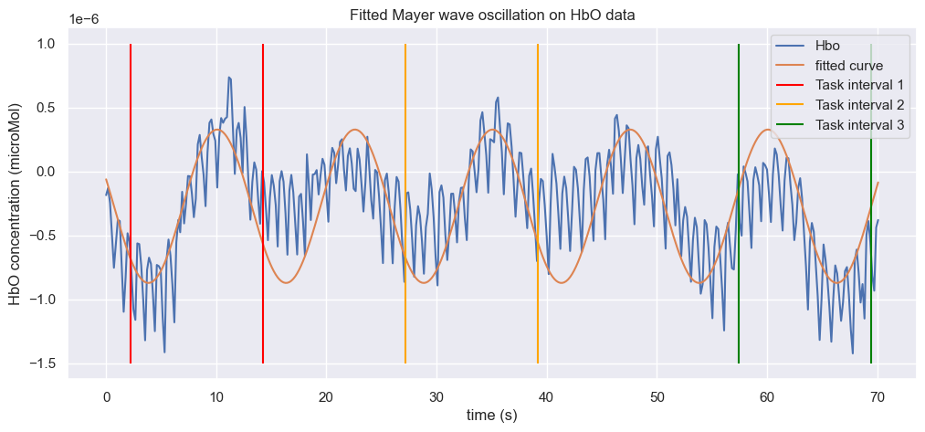

```python
%matplotlib inline
plt.figure(figsize = (12,5))
t_start, t_stop = 670,740
t_start*raw_haemo.info['sfreq']
condition1 = events[:,0] > t_start*raw_haemo.info['sfreq']
condition2 = events[:,0] < t_stop*raw_haemo.info['sfreq']
start_interval = events[np.where(np.logical_and(condition1, condition2))[0]][:,0]/raw_haemo.info['sfreq'] - t_start
print('Interstimulus interval 1: ' +str(round(start_interval[1]-start_interval[0] - 12,2)))
print('Interstimulus interval 2: ' +str(round(start_interval[2]-start_interval[1] - 12,2)))
data_channel_S5_D3_hbo = raw_haemo.copy().pick(picks = 16).crop(t_start, t_stop).get_data()[0]
t = np.arange(len(data_channel_S5_D3_hbo))/raw_haemo.info['sfreq']
f = 0.08 # Hz
sin = 6e-7*np.sin(2*np.pi*f*t-3.5) + np.mean(data_channel_S5_D3_hbo)
plt.plot(t, data_channel_S5_D3_hbo, label = 'Hbo')
plt.plot(t, sin, label = 'fitted curve')
plt.vlines( [start_interval[0], start_interval[0] + 12], ymin = -1.5e-6, ymax = 1e-6, color = 'red', label = 'Task interval 1')
plt.vlines( [start_interval[1], start_interval[1] + 12], ymin = -1.5e-6, ymax = 1e-6, color = 'orange', label = 'Task interval 2')
plt.vlines( [start_interval[2], start_interval[2] + 12], ymin = -1.5e-6, ymax = 1e-6, color = 'green', label = 'Task interval 3')
plt.xlabel('time (s)')
plt.xlabel('time (s)')
plt.xlabel('time (s)')
plt.ylabel('HbO concentration (microMol)')
plt.title('Fitted Mayer wave oscillation on HbO data')
plt.legend()
if export:
    plt.savefig('FTT3_VI_2.png')
```

#### Physiological noise

- Mayerwaves and heart beats are clearly visible

#### Spikes

- Few spikes are present across multiple channels at timepoints

#### Baseline shifts

- Some baseline shifts at the beginning of the recording

#### Baseline drifts

- Not present

### Signal quality metrics and channel rejection

#### Scalp Coupling Index

The SCI is a quality measurement of the connection between the optodes and the scalp of the participant using the strong cardiac oscillation in raw fNIRS signals. With a sufficiently high sampling rate (e.g.: 10 Hz), the heartbeat emerges as a dependable marker for evaluating optode-scalp coupling. It was first introduced by Pollonini et al. (2013) and it assesses the synchronous cardiac pulsation in the two photodetected signals (760 and 850 nm) in the cardiac band (0.5 - 2.5 Hz). After the bandpass-filtering the resulting signals are normalized to balance any difference between their amplitude. Finally, the zero-lag cross-correlation between photodetected signals of the same channel is used as a quantitative measure of the SNR of that specific channel. A threshold of SCI $>$ 0.75 is recommended by the authors.

##### SCI evaluated over complete signal

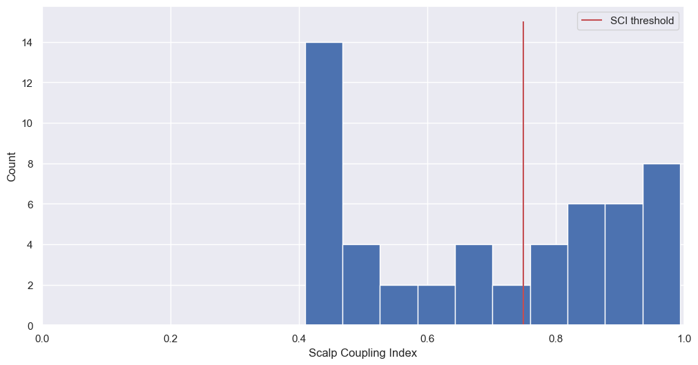

```python
# Calculate SCI with build-in function of mne_nirs
sci = scalp_coupling_index(raw_od, l_freq=0.7, h_freq=1.5, l_trans_bandwidth=0.3, h_trans_bandwidth=0.3, verbose=False)
# SCI bandpasses the signal with a FIR filter: l_freq=0.7, h_freq=1.5, l_trans_bandwidth=0.3, h_trans_bandwidth=0.3

# Plot histogram of SCI values
%matplotlib inline
fig, ax = plt.subplots(figsize=(12,6))
ax.hist(sci)
ax.set(xlabel='Scalp Coupling Index', ylabel='Count', xlim=[0, 1])
plt.vlines(0.75, ymin = 0, ymax = 15, color = 'r', label = 'SCI threshold')
plt.legend()
if export:
    plt.savefig('FTT3_SCI.png')
plt.show()
```

```python
# Copy raw object to apply SCI
raw_od_SCI = raw_od.copy()
# Mark channels with SCI < 0.75 as BAD
raw_od_SCI.info['bads'] = list(compress(raw_od.ch_names, sci < 0.75)) # 0.75 RECOMMENDED BY Pollonini et al. (2013)
print('The ' + str(len(raw_od_SCI.info['bads'])) + ' bad channels are: ' + str(raw_od_SCI.info['bads']))
```

```
The 28 bad channels are: ['S1_D1 760', 'S1_D1 850', 'S3_D1 760', 'S3_D1 850', 'S5_D1 760', 'S5_D1 850', 'S6_D2 760', 'S6_D2 850', 'S7_D1 760', 'S7_D1 850', 'S6_D4 760', 'S6_D4 850', 'S4_D6 760', 'S4_D6 850', 'S6_D6 760', 'S6_D6 850', 'S2_D8 760', 'S2_D8 850', 'S3_D7 760', 'S3_D7 850', 'S1_D9 760', '…
```

```python
# Inspect bad channels (grey color)
if plot:
    %matplotlib qt
    raw_od_SCI.plot(duration=300, show_scrollbars = True, clipping = None);
```

```
Channels marked as bad:
['S1_D1 760', 'S1_D1 850', 'S3_D1 760', 'S3_D1 850', 'S5_D1 760', 'S5_D1 850', 'S6_D2 760', 'S6_D2 850', 'S7_D1 760', 'S7_D1 850', 'S6_D4 760', 'S6_D4 850', 'S4_D6 760', 'S4_D6 850', 'S6_D6 760', 'S6_D6 850', 'S2_D8 760', 'S2_D8 850', 'S3_D7 760', 'S3_D7 850', 'S1_D9 760', 'S1_D9 850', 'S2_D10 760',…
```

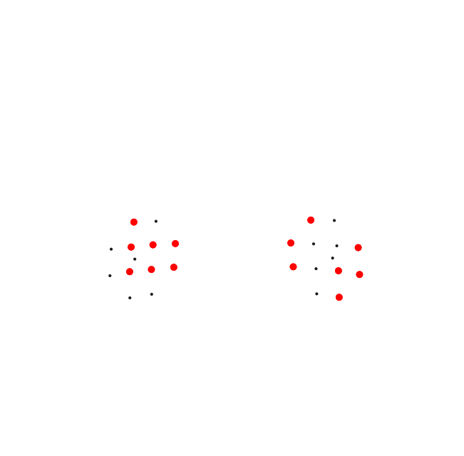

```python
# Bad channels are now displayed in red
%matplotlib inline
fig = raw_od_SCI.plot_sensors()
if export:
    fig.savefig('FTT3_SCI_topomap.png')
```

```python
# Look at characteristics
raw_od_SCI
```

**General**

| Measurement date | May 08, 2024 12:56:44 GMT |
| --- | --- |
| Experimenter | Unknown |
| Participant |  |

**Channels**

| Digitized points | 20 points |
| --- | --- |
| Good channels | 24 fNIRS (OD) |
| Bad channels | S1_D1 760, S1_D1 850, S3_D1 760, S3_D1 850, S5_D1 760, S5_D1 850, S6_D2 760, S6_D2 850, S7_D1 760, S7_D1 850, S6_D4 760, S6_D4 850, S4_D6 760, S4_D6 850, S6_D6 760, S6_D6 850, S2_D8 760, S2_D8 850, S3… |
| EOG channels | Not available |
| ECG channels | Not available |

**Data**

| Sampling frequency | 5.65 Hz |
| --- | --- |
| Highpass | 0.00 Hz |
| Lowpass | 2.82 Hz |
| Filenames | romane_vorwald fft_22_20240508-125644.snirf |
| Duration | 00:21:09 (HH:MM:SS) |

> *Remark:*
- 28 channels are marked as bad
- Although heartrate visually present in recordings

##### SCI evaluated over moving window

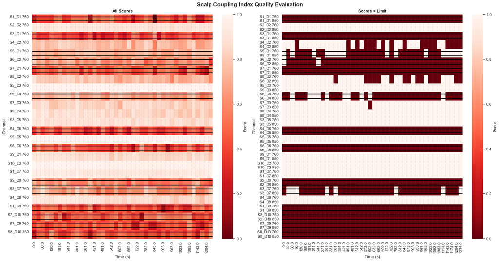

```python
# Calculate windowed SCI with windows of 30 s
_, scores, times = scalp_coupling_index_windowed(raw_od_SCI, time_window=30)

%matplotlib inline
# Plot
plot_timechannel_quality_metric(raw_od_SCI, scores, times, threshold=0.75, title="Scalp Coupling Index Quality Evaluation");
```

#### Peak Spectral Power

Pollonini et al. (2016) state that to enhance the reliability of a quantitative measure for scalp coupling, the spectral power of the cross-correlated signal can serve as an additional indicator of cardiac signal strength. By setting a spectral power threshold, it becomes possible to objectively differentiate between a clear optical channel and a noisy one. Theoretically, photodetected cardiac signals can be conceptualized as two sinusoidal waves oscillating at the physiological frequency $f_{cardiac}$ (e.g.: 1 Hz or 60 bpm) with arbitrary amplitude and offset. The resultant normalized cross-correlation signal ($\overline{x_{\lambda_1}} \otimes \overline{x_{\lambda_2}}$) exhibits unity amplitude, a frequency of $f_{cardiac}$ and a peak power of 0.5. Therefore, a threshold can be established at a certain fraction of the ideal peak power. However, in practice, cardiac photoplethysmographic signals are not strictly sinusoidal and may contain quantization noise, which reduces the peak power value. Hence, the authors recommend empirically setting the threshold value at 0.1.

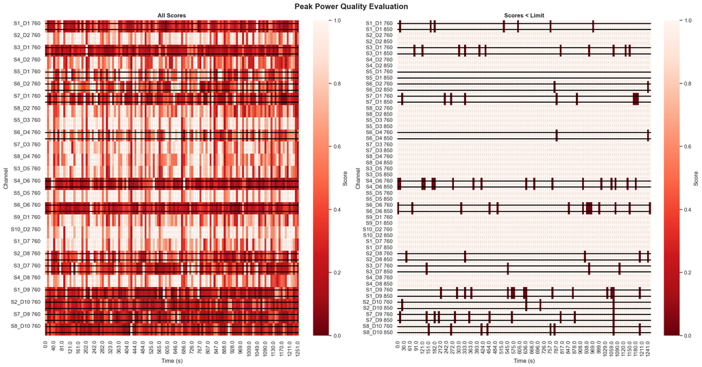

```python
# View instances where a subset of channels may be contaminated by artifacts for a short duration of the recording
raw_od_SCI_PSP, scores, times = peak_power(raw_od_SCI, time_window=10)

# Plot
%matplotlib inline
plot_timechannel_quality_metric(raw_od_SCI_PSP, scores, times, threshold=0.1, title="Peak Power Quality Evaluation"); #see PHOEBE
```

```python
# Check that PP was indicated where the bad segments of data are
if plot:
    %matplotlib qt
    raw_od_SCI_PSP.plot(duration=100, show_scrollbars = True, clipping = None);
```

```python
# In dataframe format
raw_od_SCI_PSP.annotations.to_data_frame()
```

|  | onset | duration | description | ch_names |
| --- | --- | --- | --- | --- |
| 0 | 2024-05-08 12:56:44.000000000 | 10.000000 | BAD_PeakPower | (S4_D6 760, S4_D6 850) |
| 1 | 2024-05-08 12:56:44.000000000 | 10.000000 | BAD_PeakPower | (S6_D6 760, S6_D6 850) |
| 2 | 2024-05-08 12:56:54.089000000 | 10.000000 | BAD_PeakPower | (S1_D1 760, S1_D1 850) |
| 3 | 2024-05-08 12:56:54.089000000 | 10.000000 | BAD_PeakPower | (S4_D6 760, S4_D6 850) |
| 4 | 2024-05-08 12:56:54.089000000 | 10.000000 | BAD_PeakPower | (S7_D9 760, S7_D9 850) |
| ... | ... | ... | ... | ... |
| 159 | 2024-05-08 13:17:24.509236620 | 27.381651 | BAD_manual | () |
| 160 | 2024-05-08 13:17:24.947000000 | 10.000000 | BAD_PeakPower | (S2_D8 760, S2_D8 850) |
| 161 | 2024-05-08 13:17:24.947000000 | 10.000000 | BAD_PeakPower | (S6_D2 760, S6_D2 850) |
| 162 | 2024-05-08 13:17:24.947000000 | 10.000000 | BAD_PeakPower | (S6_D4 760, S6_D4 850) |
| 163 | 2024-05-08 13:17:35.036000000 | 10.000000 | BAD_PeakPower | (S6_D6 760, S6_D6 850) |

164 rows × 4 columns

> *Remark:*
- All segments with a PSP value under 0.1 were located in channels that were already indicated by the SCI method as bad channels
- No extra segments will be removed from the analysis